# Homework 1 Solutions

Matt Lukac

October 25, 2018

## Identifying Variables

For the entirety of this homework, we will be using the `tidyverse` package. To examine the variables and determine their characteristics, we use the `read_csv` and `head` functions.

```r
library(tidyverse)

RNAseq <- read_csv("HW_RNAseq.csv") # Read in csv file as a tibble
head(RNAseq) # View the top chunk of the tibble
```

```
## # A tibble: 6 x 14
##   SampleID Population Treatment Sex   Gene01 Gene02 Gene03 Gene04 Gene05
##   <chr>    <chr>      <chr>     <chr>  <dbl>  <dbl>  <dbl>  <dbl>  <dbl>
## 1 BtCV1    Boot       Conventi~ male    357.   203.   413.  113.   139.
## 2 BtCV2    Boot       Conventi~ male    349.   298.   385.  109.   126.
## 3 BtCV3    Boot       Conventi~ fema~   361.   297.   389.   94.0  142.
## 4 BtCV4    Boot       Conventi~ fema~   448.   214.   332.  131.   228.
## 5 BtCV5    Boot       Conventi~ male    471.   227.   337.   96.7  214.
## 6 BTMA1    Boot       MonoAssoc male    258.   368.   422.  117.    70.2
## # ... with 5 more variables: Gene06 <dbl>, Gene07 <dbl>, Gene08 <dbl>,
## #   Gene09 <dbl>, Gene10 <dbl>
```

From here we can read off the variables and note that the first column is simply the individuals (the fish) in the study. The first three variables are stored as character strings and hence are categorical variables. The remaining ten variables, all stored as doubles, are continuous variables. Since this study aims to measure how different populations, treatments, and sexes can affect the gene expressions for stickleback fish, we conclude that said categorical variables are all explanatory and the gene expressions represent our response variables.

## Determining Distributions

We want to determine the distributions for each continuous variable. To do this, we organize the histograms in a $2\times 5$ grid, using the `par` function in conjunction with the `mfrow` function. Observe:

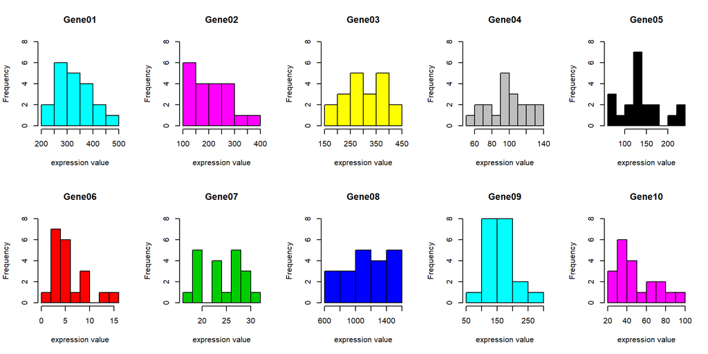

```r
par(mfrow = c(2,5))
for(i in 5:14){
  gene <- RNAseq[[i]]
  name <- colnames(RNAseq[i])
  hist(gene, ylim=c(0,8), main=name, xlab="expression value", col = i)
}
```

Now, there are only 20 observations per variable, so it is difficult to make any assertions about the above distributions just by looking at them. Moreover, the individuals observed come from different strata of the population and hence the gene expressions may also be stratified. Gene 7, for example, appears to have two peaks.

## z-Scores and Their Distributions

For any fixed gene, let $x_i$ represent the $i$th fishes gene expression, $\overline{x}$ represent the sample mean, and let $s$ be the sample standard deviation. Then we want to compute
$$z_i = \frac{x_i - \overline{x}}{s}.$$
To implement this in `R`, we can use the `scale` function to compute $z_i$ for each fish in each gene.

```r
# Add z scores to the end of RNAseq
for(i in 1:10){
  RNAseq[,i+14] <- scale(RNAseq[[i+4]])
  names(RNAseq)[i+14] <- paste0('zGene', i)
}
```

Finally, we can view the histograms for the standardized values of the first two genes.

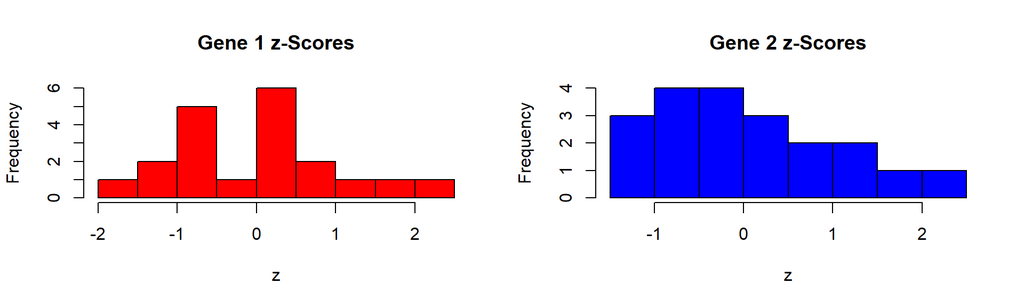

```r
par(mfrow = c(1,2))
  hist(RNAseq$zGene1, col = "red", xlab = "z", main = "Gene 1 z-Scores")
  hist(RNAseq$zGene2, col = "blue", xlab = "z", main = "Gene 2 z-Scores")
```

## Boxplots

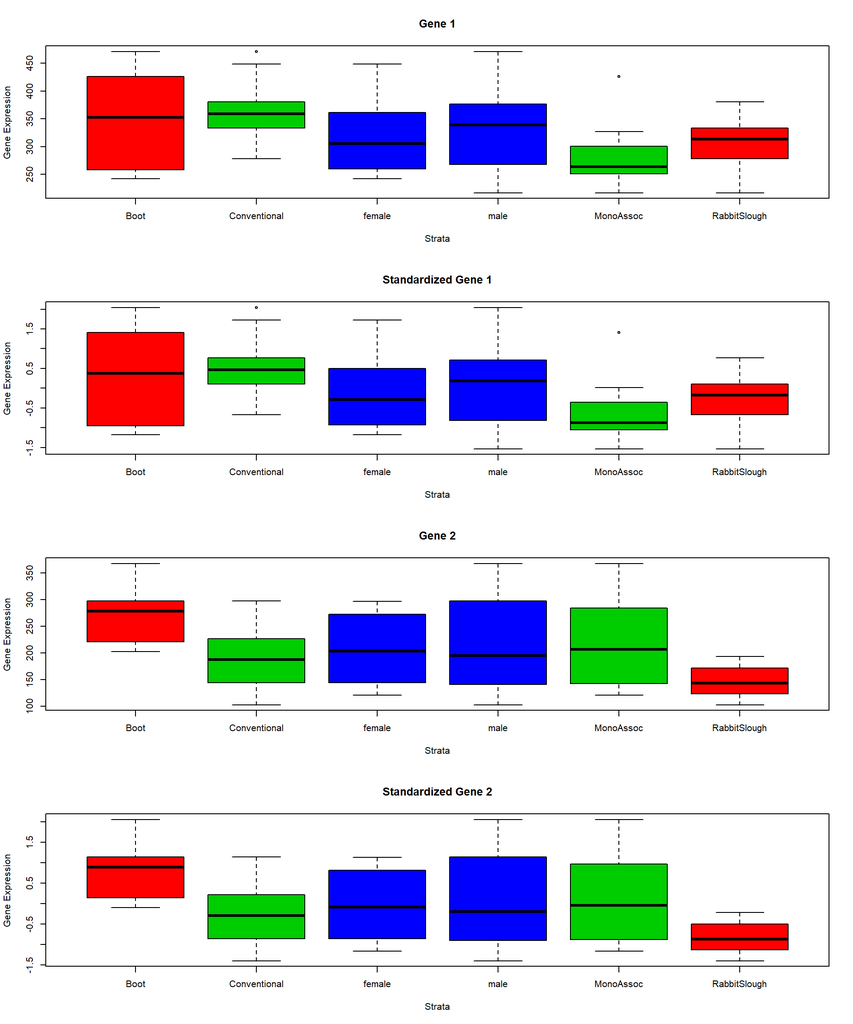

```r
par(mfrow = c(4,1))
boxplot(c(Gene01, Gene01, Gene01)~c(Population, Treatment, Sex), data = RNAseq,
        col = c(2,3,4,4,3,2), xlab = "Strata", ylab = "Gene Expression", main = "Gene 1"
        )
boxplot(c(zGene1, zGene1, zGene1)~c(Population, Treatment, Sex), data = RNAseq,
        col = c(2,3,4,4,3,2), xlab = "Strata", ylab = "Gene Expression", main="Standardized Gene 1"
        )
boxplot(c(Gene02, Gene02, Gene02)~c(Population, Treatment, Sex), data = RNAseq,
        col = c(2,3,4,4,3,2), xlab = "Strata", ylab = "Gene Expression", main = "Gene 2"
        )
boxplot(c(zGene2, zGene2, zGene2)~c(Population, Treatment, Sex), data = RNAseq,
        col = c(2,3,4,4,3,2), xlab = "Strata", ylab = "Gene Expression", main="Standardized Gene 2"
        )
```

## Descriptive Statistics

We will use `tapply` to calculate the mean, variance, and standard deviation for each strata.

```r
des_stats <- NULL
for(i in 5:14){
  gene <- RNAseq[,i]
  name <- colnames(RNAseq[i])
  mean_pop <- tapply(RNAseq[[i]], RNAseq$Population, mean)
  var_pop <- tapply(RNAseq[[i]], RNAseq$Population, var)
  sd_pop <- tapply(RNAseq[[i]], RNAseq$Population, sd)
  mean_trt <- tapply(RNAseq[[i]], RNAseq$Treatment, mean)
  var_trt <- tapply(RNAseq[[i]], RNAseq$Treatment, var)
  sd_trt <- tapply(RNAseq[[i]], RNAseq$Treatment, sd)
  mean_sex <- tapply(RNAseq[[i]], RNAseq$Sex, mean)
  var_sex <- tapply(RNAseq[[i]], RNAseq$Sex, var)
  sd_sex <- tapply(RNAseq[[i]], RNAseq$Sex, sd)

  gene_stats <- c(mean_pop,var_pop,sd_pop,mean_trt,var_trt,sd_trt,mean_sex,var_sex,sd_sex)
  des_stats <- as.data.frame(rbind(des_stats,gene_stats))
}

#Add row names corresponding to the genes
row.names(des_stats) <- colnames(RNAseq)[5:14]

#Change the column names in the des_stats data frame to something that makes sense
factorlev <- c(rep(c("Bt","RS"),3),rep(c("Conventional","MonoAssoc"),3),rep(c("Female","Male"),3))
stat <- rep(c(rep("mean",2),rep("var",2),rep("sd",2)),3)
colnames(des_stats) <- paste(factorlev,stat, sep="_")

print(des_stats)
```

```
##           Bt_mean     RS_mean       Bt_var       RS_var      Bt_sd
## Gene01  343.03259  308.578975   7377.86736 2.613627e+03  85.894513
## Gene02  272.11741  148.880619   3068.70026 8.615398e+02  55.395851
## Gene03  372.29684  238.360695   1159.72290 1.059946e+03  34.054705
## Gene04  109.50229   85.980212    332.63172 4.747490e+02  18.238194
## Gene05  134.89508  137.299882   3081.36513 1.494487e+03  55.510045
## Gene06    8.13349    3.553174     17.12029 9.075025e-01   4.137668
## Gene07   26.26388   21.616057      9.64286 1.773729e+01   3.105296
## Gene08 1147.47796 1147.821997 116158.52225 5.511182e+04 340.820367
## Gene09  200.59180  121.843696   1734.97523 3.301621e+02  41.653034
## Gene10   62.38328   36.912418    502.88493 6.986916e+01  22.425096
##              RS_sd Conventional_mean MonoAssoc_mean Conventional_var
## Gene01  51.1236482        368.332918     283.278651       3167.82492
## Gene02  29.3519978        193.985764     227.012266       4477.90290
## Gene03  32.5568047        304.582564     306.074968       6154.36865
## Gene04  21.7887362         93.477272     102.005234        431.42009
## Gene05  38.6585930        160.043125     112.151837       1977.99523
## Gene06   0.9526293          6.326932       5.359733         16.96065
## Gene07   4.2115667         24.261899      23.618038         23.95352
## Gene08 234.7590602       1335.952041     959.347916      41755.00536
## Gene09  18.1703640        170.198892     152.236605       3445.30976
## Gene10   8.3587772         55.820898      43.474799        558.15366
##        MonoAssoc_var Conventional_sd MonoAssoc_sd Female_mean   Male_mean
## Gene01    3464.12731       56.283434    58.856837  321.097746  330.513823
## Gene02    7283.75773       66.917135    85.344934  206.269510  214.728520
## Gene03    6030.11238       78.449784    77.653798  296.290800  314.366732
## Gene04     642.93966       20.770655    25.356255   99.152774   96.329732
## Gene05    1326.86098       44.474658    36.426103  137.215710  134.979252
## Gene06      12.20260        4.118331     3.493222    6.295446    5.391218
## Gene07      15.19758        4.894233     3.898407   24.228140   23.651797
## Gene08   50720.58413      204.340415   225.212309 1080.277059 1215.022897
## Gene09    1885.72776       58.696761    43.424967  166.178307  156.257190
## Gene10     290.34413       23.625276    17.039487   50.950589   48.345109
##         Female_var     Male_var  Female_sd    Male_sd
## Gene01  5237.59936   5364.11170  72.371261  73.240096
## Gene02  3924.27955   8403.60051  62.644070  91.671154
## Gene03  4824.07692   7180.11965  69.455575  84.735587
## Gene04   595.12206    515.21357  24.395124  22.698316
## Gene05  1839.61330   2736.67271  42.890713  52.313217
## Gene06    15.98172     13.24700   3.997714   3.639643
## Gene07    10.78193     28.41494   3.283585   5.330566
## Gene08 58342.68775 102840.80498 241.542310 320.688018
## Gene09  3658.26183   1797.33967  60.483567  42.395043
## Gene10   629.30602    300.10157  25.085973  17.323440
```